# C_exp_1

# Means plots

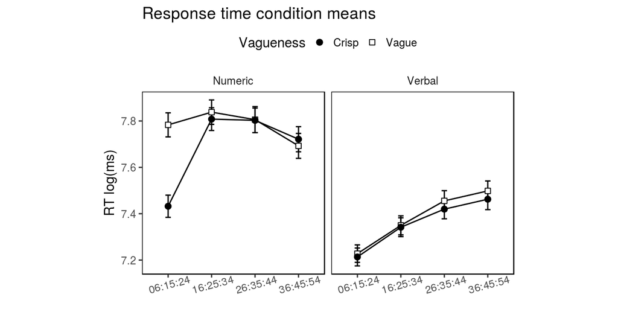

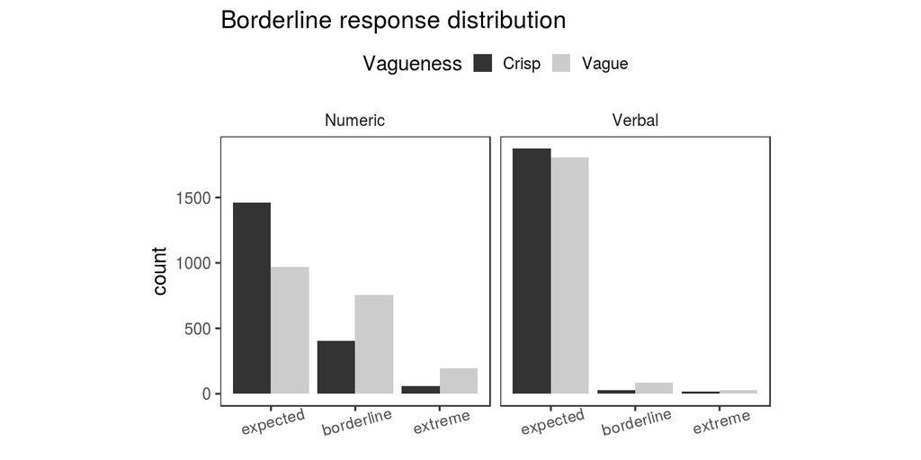

# Hypotheses

We formulated the following hypotheses for Experiment 1:

- [Hypothesis 1] Crisp/Vague RT:
  - Vague instructions should result in faster responses than crisp instructions; and this pattern should hold when the model is restricted to numeric-only data and when it is restricted to verbal-only data.
- [Hypothesis 2] Numeric/Verbal RT:
  - There should be no real difference between responses to Numeric instructions and Verbal instructions (based on our interpretation of pilot experiment B, where we thought that vague instructions alone were driving the advantage for instructions that were both vague, and also in verbal format).
- [Hypothesis 3] Item RT:
  - Responses should take longer as the number of dots in the display grows larger (i.e., as the levels of Item increase).
- [Hypothesis 4] Crisp/Vague Response Type:
  - Vague instructions should lead to more borderline responses than crisp instructions.

# Results

## Full data

Original full model

```r
dat_model <- dat
dat_model$c_Vag <- ifelse(dat_model$Vagueness=="Crisp", -0.5, 0.5)
dat_model$c_Num <- ifelse(dat_model$Number=="Verbal", -0.5, 0.5)
dat_model$c_Itm <- ifelse(dat_model$Item=="06:15:24", -.75, ifelse(dat_model$Item=="16:25:34", -.25, ifelse(dat_model$Item=="26:35:44", .25, .75)))
rtFullModel <- lmerTest::lmer(1 + RT_log ~ c_Vag * c_Num + c_Itm + (1 + c_Vag * c_Num + c_Itm | Subject), dat_model)
pretty_coef_table(rtFullModel, "rtFullModel")
```

rtFullModel

| term | 𝛽 | s.e. | d.f. | 𝑡 | 𝑝 | Pr(>\|t\|) | sig. |
| --- | --- | --- | --- | --- | --- | --- | --- |
| c_Vag | 0.058 | 0.013 | 28.99 | 4.55 | 8.87e-05 | <0.001 | ＊＊＊ |
| c_Num | 0.365 | 0.072 | 29.00 | 5.08 | 2.03e-05 | <0.001 | ＊＊＊ |
| c_Itm | 0.120 | 0.017 | 28.98 | 7.11 | 8.12e-08 | <0.001 | ＊＊＊ |
| c_Vag:c_Num | 0.069 | 0.027 | 29.04 | 2.53 | 1.69e-02 | <0.05 | ＊ |

Numeric only

```r
dat_model <- droplevels(subset(dat, Number=="Numeric"))
dat_model$c_Vag <- ifelse(dat_model$Vagueness=="Crisp", -0.5, 0.5)
dat_model$c_Itm <- ifelse(dat_model$Item=="06:15:24", -.75, ifelse(dat_model$Item=="16:25:34", -.25, ifelse(dat_model$Item=="26:35:44", .25, .75)))
rtFullModel_num <- lmerTest::lmer(1 + RT_log ~ c_Vag + c_Itm + (1 + c_Vag + c_Itm | Subject), dat_model)
pretty_coef_table(rtFullModel_num, "rtFullModel_num")
```

rtFullModel_num

| term | 𝛽 | s.e. | d.f. | 𝑡 | 𝑝 | Pr(>\|t\|) | sig. |
| --- | --- | --- | --- | --- | --- | --- | --- |
| c_Vag | 0.093 | 0.021 | 28.77 | 4.51 | 9.99e-05 | <0.001 | ＊＊＊ |
| c_Itm | 0.064 | 0.024 | 28.79 | 2.66 | 1.27e-02 | <0.05 | ＊ |

Verbal only

```r
dat_model <- droplevels(subset(dat, Number=="Verbal"))
dat_model$c_Vag <- ifelse(dat_model$Vagueness=="Crisp", -0.5, 0.5)
dat_model$c_Itm <- ifelse(dat_model$Item=="06:15:24", -.75, ifelse(dat_model$Item=="16:25:34", -.25, ifelse(dat_model$Item=="26:35:44", .25, .75)))
rtFullModel_verb <- lmerTest::lmer(1 + RT_log ~ c_Vag + c_Itm + (1 + c_Vag + c_Itm | Subject), dat_model)
pretty_coef_table(rtFullModel_verb, "rtFullModel_verb")
```

rtFullModel_verb

| term | 𝛽 | s.e. | d.f. | 𝑡 | 𝑝 | Pr(>\|t\|) | sig. |
| --- | --- | --- | --- | --- | --- | --- | --- |
| c_Vag | 0.024 | 0.016 | 29.03 | 1.46 | 1.55e-01 | 0.155 |  |
| c_Itm | 0.175 | 0.016 | 28.88 | 11.04 | 7.02e-12 | <0.001 | ＊＊＊ |

Borderline model

```r
dat_model <- dat_borderline
dat_model$c_Vag <- ifelse(dat_model$Vagueness=="Crisp", -0.5, 0.5)
dat_model$c_Num <- ifelse(dat_model$Number=="Verbal", -0.5, 0.5)
dat_model$c_Itm <- ifelse(dat_model$Item=="06:15:24", -.75, ifelse(dat_model$Item=="16:25:34", -.25, ifelse(dat_model$Item=="26:35:44", .25, .75)))
blFullModel <- lme4::glmer(isBorderline ~ c_Vag * c_Num + c_Itm + (1 + c_Vag * c_Num + c_Itm | Subject), dat_model, family="binomial", control = glmerControl(optimizer = "bobyqa"))
pretty_coef_table(blFullModel, "blFullModel")
```

blFullModel

| term | 𝛽 | s.e. | 𝑧 | 𝑝 | Pr(>\|z\|) | sig. |
| --- | --- | --- | --- | --- | --- | --- |
| c_Vag | 0.66 | 0.224 | 2.96 | 3.13e-03 | <0.01 | ＊＊ |
| c_Num | 3.33 | 0.226 | 14.71 | 5.87e-49 | <0.001 | ＊＊＊ |
| c_Itm | 0.38 | 0.098 | 3.84 | 1.21e-04 | <0.001 | ＊＊＊ |
| c_Vag:c_Num | 0.69 | 0.420 | 1.64 | 1.02e-01 | 0.102 |  |

## Data less 6:15:24

However, given that the plot shows that responses to 6:15:24 in the “crisp numeric” instructions condition were extremely fast relative to the “vague numeric” instructions to 6:15:24, the effects in the model of the full dataset could be driven by this difference.

A clearer picture of the effects of interest might be obtained by removing the 6:15:24 level of Item from the data set, and fitting the model to this restricted data. Doing this results in the effects tabled below.

Model of the data after the 6:15:24 level of Item is removed

```r
dat_model <- droplevels(subset(dat, Item!="06:15:24"))
dat_model$c_Vag <- ifelse(dat_model$Vagueness=="Crisp", -0.5, 0.5)
dat_model$c_Num <- ifelse(dat_model$Number=="Verbal", -0.5, 0.5)
dat_model$c_Itm <- ifelse(dat_model$Item=="16:25:34", -.3333, ifelse(dat_model$Item=="26:35:44", .0000, .3333))
rtRestrictedModel <- lmerTest::lmer(1 + RT_log ~ c_Vag * c_Num + c_Itm + (1 + c_Vag + c_Num  | Subject), dat_model)
pretty_coef_table(rtRestrictedModel, "rtRestrictedModel")
```

rtRestrictedModel

| term | 𝛽 | s.e. | d.f. | 𝑡 | 𝑝 | Pr(>\|t\|) | sig. |
| --- | --- | --- | --- | --- | --- | --- | --- |
| c_Vag | 0.015 | 0.013 | 186.49 | 1.18 | 2.40e-01 | 0.24 |  |
| c_Num | 0.359 | 0.076 | 29.00 | 4.70 | 5.80e-05 | <0.001 | ＊＊＊ |
| c_Itm | 0.023 | 0.023 | 5493.08 | 0.99 | 3.23e-01 | 0.323 |  |
| c_Vag:c_Num | -0.022 | 0.025 | 5493.11 | -0.89 | 3.74e-01 | 0.374 |  |

Numeric only after the 6:15:24 level of Item is removed

```r
dat_model <- droplevels(subset(dat, Item!="06:15:24" & Number=="Numeric"))
dat_model$c_Vag <- ifelse(dat_model$Vagueness=="Crisp", -0.5, 0.5)
dat_model$c_Itm <- ifelse(dat_model$Item=="16:25:34", -.3333, ifelse(dat_model$Item=="26:35:44", .0000, .3333))
rtRestrictedModel_num <- lmerTest::lmer(1 + RT_log ~ c_Vag + c_Itm + (1 + c_Vag | Subject), dat_model)
pretty_coef_table(rtRestrictedModel_num, "rtRestrictedModel_num")
```

rtRestrictedModel_num

| term | 𝛽 | s.e. | d.f. | 𝑡 | 𝑝 | Pr(>\|t\|) | sig. |
| --- | --- | --- | --- | --- | --- | --- | --- |
| c_Vag | 0.0049 | 0.020 | 626.61 | 0.25 | 8.03e-01 | 0.803 |  |
| c_Itm | -0.1644 | 0.036 | 2676.03 | -4.60 | 4.39e-06 | <0.001 | ＊＊＊ |

Verbal-only after the 6:15:24 level of Item is removed

```r
dat_model <- droplevels(subset(dat, Item!="06:15:24" & Number=="Verbal"))
dat_model$c_Vag <- ifelse(dat_model$Vagueness=="Crisp", -0.5, 0.5)
dat_model$c_Itm <- ifelse(dat_model$Item=="16:25:34", -.3333, ifelse(dat_model$Item=="26:35:44", .0000, .3333))
rtRestrictedModel_verb <- lmerTest::lmer(1 + RT_log ~ c_Vag + c_Itm + (1 + c_Vag + c_Itm | Subject), dat_model)
pretty_coef_table(rtRestrictedModel_verb, "rtRestrictedModel_verb")
```

rtRestrictedModel_verb

| term | 𝛽 | s.e. | d.f. | 𝑡 | 𝑝 | Pr(>\|t\|) | sig. |
| --- | --- | --- | --- | --- | --- | --- | --- |
| c_Vag | 0.026 | 0.019 | 31.21 | 1.41 | 1.70e-01 | 0.17 |  |
| c_Itm | 0.202 | 0.031 | 109.46 | 6.57 | 1.75e-09 | <0.001 | ＊＊＊ |

On the basis of the restricted model:

- [Hypothesis 1] Crisp/Vague RT:
  - after dropping the 6:15:24 level, there is still a disadvantage for Vagueness, but it is not significant (p=.24).
  - When the model was restricted to numeric-only instructions the disadvantage for vagueness was very small and not significant.
  - When the model was restricted to verbal-only instructions the disadvantage for vagueness was small and not significant.
- [Hypothesis 2] Numeric/Verbal RT:
  - There is still a significant disadvantage for Numeric instruction format (p<.001).
- [Hypothesis 3] Item RT:
  - There is still a disadvantage for increasing the number of dots but it is not significant (p=.323).
- The interaction between Vagueness and Instruction format changes sign, and is now non-significant (beta=-.022, p=.374).

# Discussion

This experiment tested whether vague instructions would result in faster responses than crisp instructions, when borderline cases were present. Faster responses for vague instructions were found in pilot experiment B, but there were no borderline cases in that experiment.

In this experiment we found in contrast that vague instructions resulted in slower responses than crisp instructions: a difference that was significant when considering the full data (112ms), but which was not significant after removing the smallest arrays from the analysis, which had a pattern opposite to the main trends in the rest of the data.

We also found that the effect of instruction format was significant, with numerical format slowing responses by 689 ms on average, such that the disadvantage of numerical format overwhelmed the contribution of vagueness. The verbal vague condition still yielded faster responses than the numerical crisp condition, so the pattern from pilot experiment B was reproduced, but in the light of the evidence from this experiment (Experiment 1), in the presence of borderline cases, the advantage that was ascribed to vagueness before now looks more like an advantage of verbal instruction format.

However, once again there is a possibly confounding factor. Observe that, in Experiment 1, instruction format (i.e., the difference between numeric and verbal) went hand in hand with might be called the (human) “selection algorithm”: To see this, consider the task of selecting the dot array that contains “few dots”:" to do this, it suffices to *compare* the three arrays and select the one that contains the fewest elements. To select the dot array that contains “16 dots” seems to require the participant to estimate, and then *match*, the cardinality of (at least) one dot array to 16, a process which could plausibly take longer, independently of vagueness. Therefore, our results so far permit the interpretation that what made the instructions in the verbal condition fast is not the fact that they were worded verbally, but that they allowed participants to use *comparison* rather than having to resort to *matching*.

In the next two experiments we pitted the comparison algorithm and matching algorithm selection tasks against each other while controlling vagueness and instruction format. In Experiment 2 we restricted all the instructions to numeric quantifiers while factorially manipulating vagueness and selection task. In Experiment 3 we ensured that all instructions used verbal quantifiers, while also factorially manipulating vagueness and selection task. This allowed us to distinguish between the predictions of the selection task account and the instruction format account.